# 회귀분석 중간고사

20180968 박서현

2020 10 27

```r
#install.packages('DescTools')
#install.packages("car")
library(binom)
```

```r
library(ggplot2)
library(PropCIs)
library(data.table)
library(readxl)
library(epitools)
library(DescTools)
library(dplyr)
library(MASS)
library(car)
library(lmtest)
```

# 1.

```r
x <- c(64, 80, 83, 87, 87, 87)
y <- c(35, 51, 58, 58, 58, 59)

df1 <- data.frame(x, y)
df1
```

```
##    x  y
## 1 64 35
## 2 80 51
## 3 83 58
## 4 87 58
## 5 87 58
## 6 87 59
```

## (1)

```r
cov(df1)
```

```
##          x        y
## x 80.26667 82.73333
## y 82.73333 87.76667
```

## (2)

```r
cor.test(x=df1$x, y=df1$y)
```

```
##
##  Pearson's product-moment correlation
##
## data:  df1$x and df1$y
## t = 11.702, df = 4, p-value = 0.0003049
## alternative hypothesis: true correlation is not equal to 0
## 95 percent confidence interval:
##  0.8705667 0.9985037
## sample estimates:
##       cor
## 0.9857076
```

상관계수가 0.9857076으로 상관성이 높다

## (3)

```r
res = lm(y~x)
summary(res)
```

```
##
## Call:
## lm(formula = y ~ x)
##
## Residuals:
##         1         2         3         4         5         6
## -0.300664 -0.792359  3.115449 -1.007475 -1.007475 -0.007475
##
## Coefficients:
##              Estimate Std. Error t value Pr(>|t|)
## (Intercept) -30.66611    7.19997  -4.259 0.013062 *
## x             1.03073    0.08808  11.702 0.000305 ***
## ---
## Signif. codes:  0 '***' 0.001 '**' 0.01 '*' 0.05 '.' 0.1 ' ' 1
##
## Residual standard error: 1.765 on 4 degrees of freedom
## Multiple R-squared:  0.9716, Adjusted R-squared:  0.9645
## F-statistic: 136.9 on 1 and 4 DF,  p-value: 0.0003049
```

회귀식:
$$Y = -30.66611 + 1.03073X$$

## (4)

```r
summary(res)
```

```
##
## Call:
## lm(formula = y ~ x)
##
## Residuals:
##         1         2         3         4         5         6
## -0.300664 -0.792359  3.115449 -1.007475 -1.007475 -0.007475
##
## Coefficients:
##              Estimate Std. Error t value Pr(>|t|)
## (Intercept) -30.66611    7.19997  -4.259 0.013062 *
## x             1.03073    0.08808  11.702 0.000305 ***
## ---
## Signif. codes:  0 '***' 0.001 '**' 0.01 '*' 0.05 '.' 0.1 ' ' 1
##
## Residual standard error: 1.765 on 4 degrees of freedom
## Multiple R-squared:  0.9716, Adjusted R-squared:  0.9645
## F-statistic: 136.9 on 1 and 4 DF,  p-value: 0.0003049
```

결정게수: 0.9716

## (5)

```r
summary(res)
```

```
##
## Call:
## lm(formula = y ~ x)
##
## Residuals:
##         1         2         3         4         5         6
## -0.300664 -0.792359  3.115449 -1.007475 -1.007475 -0.007475
##
## Coefficients:
##              Estimate Std. Error t value Pr(>|t|)
## (Intercept) -30.66611    7.19997  -4.259 0.013062 *
## x             1.03073    0.08808  11.702 0.000305 ***
## ---
## Signif. codes:  0 '***' 0.001 '**' 0.01 '*' 0.05 '.' 0.1 ' ' 1
##
## Residual standard error: 1.765 on 4 degrees of freedom
## Multiple R-squared:  0.9716, Adjusted R-squared:  0.9645
## F-statistic: 136.9 on 1 and 4 DF,  p-value: 0.0003049
```

MSE: 1.765의 제곱 = 3.115225 회귀모형의 적합성을 나타낸다.

## (6)

```r
coef(res)
```

```
## (Intercept)           x
##  -30.666113    1.030731
```

## (7)

```r
confint(res, level=0.90)
```

```
##                     5 %       95 %
## (Intercept) -46.0153433 -15.316883
## x             0.8429578   1.218504
```

## (8)

```r
summary(res)
```

```
##
## Call:
## lm(formula = y ~ x)
##
## Residuals:
##         1         2         3         4         5         6
## -0.300664 -0.792359  3.115449 -1.007475 -1.007475 -0.007475
##
## Coefficients:
##              Estimate Std. Error t value Pr(>|t|)
## (Intercept) -30.66611    7.19997  -4.259 0.013062 *
## x             1.03073    0.08808  11.702 0.000305 ***
## ---
## Signif. codes:  0 '***' 0.001 '**' 0.01 '*' 0.05 '.' 0.1 ' ' 1
##
## Residual standard error: 1.765 on 4 degrees of freedom
## Multiple R-squared:  0.9716, Adjusted R-squared:  0.9645
## F-statistic: 136.9 on 1 and 4 DF,  p-value: 0.0003049
```

p-value가 0.0003049로 0.05보다 작으므로 적합하다. 7에서 구한 신뢰구간과 일치하는 것을 확인할 수 있다.

## (9)

```r
pred = predict(res, newdata = data.frame(x=88))
pred
```

```
##        1
## 60.03821
```

## (10)

```r
pre = predict(res, newdata = data.frame(x=88))
pre
```

```
##        1
## 60.03821
```

```r
confint(res, level=0.90)
```

```
##                     5 %       95 %
## (Intercept) -46.0153433 -15.316883
## x             0.8429578   1.218504
```

# 2.

```r
x <- c(40, 50, 60, 70, 80, 90, 40, 60, 80, 50)
y <- c(69, 175, 272, 335, 490, 415, 72, 265, 492, 180)

df <- data.frame(x, y)
df
```

```
##     x   y
## 1  40  69
## 2  50 175
## 3  60 272
## 4  70 335
## 5  80 490
## 6  90 415
## 7  40  72
## 8  60 265
## 9  80 492
## 10 50 180
```

## (1)

```r
attach(df)
```

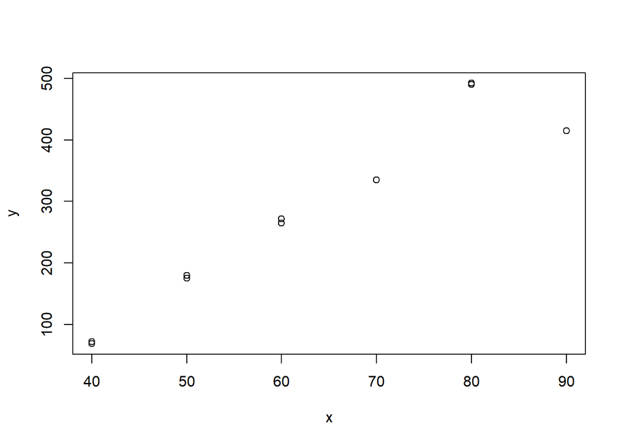

```r
plot(x, y)
```

x값이 증기함에 따라 y값도 증가한다.

## (2)

```r
result = lm(y~x)
summary(result)
```

```
##
## Call:
## lm(formula = y ~ x)
##
## Residuals:
##      Min       1Q   Median       3Q      Max
## -100.312  -15.080    3.203   10.880   61.978
##
## Coefficients:
##              Estimate Std. Error t value Pr(>|t|)
## (Intercept) -252.2971    58.7508  -4.294  0.00264 **
## x              8.5290     0.9153   9.318 1.43e-05 ***
## ---
## Signif. codes:  0 '***' 0.001 '**' 0.01 '*' 0.05 '.' 0.1 ' ' 1
##
## Residual standard error: 48.09 on 8 degrees of freedom
## Multiple R-squared:  0.9156, Adjusted R-squared:  0.9051
## F-statistic: 86.83 on 1 and 8 DF,  p-value: 1.434e-05
```

회귀식:
$$Y = -252.2971 + 8.5290X$$

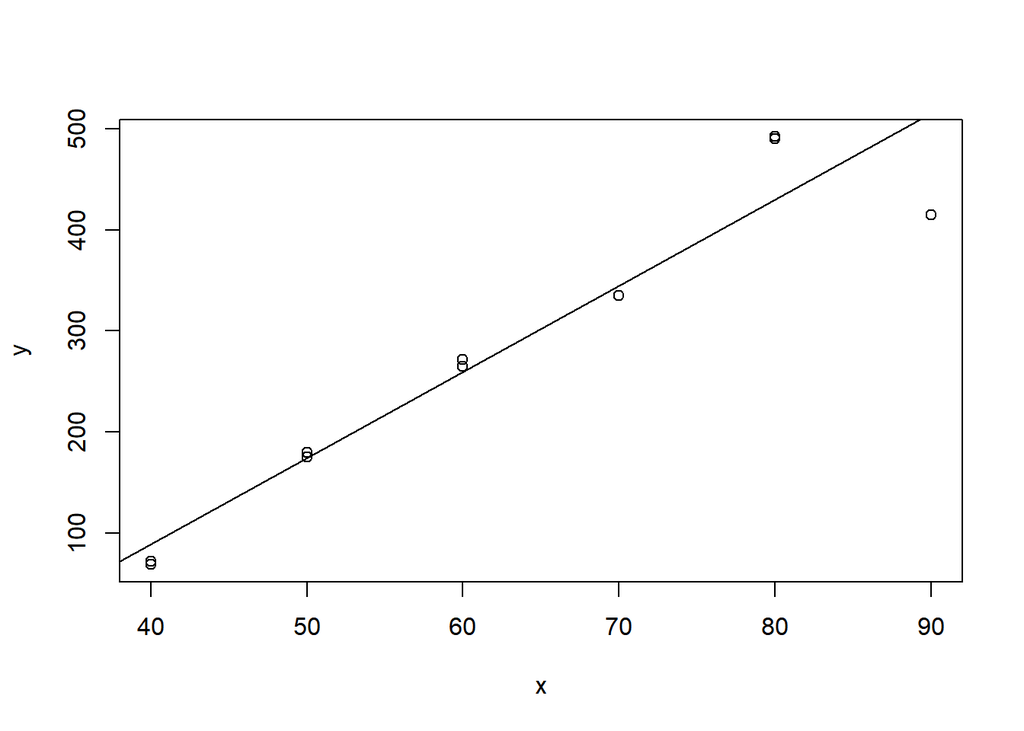

```r
plot(x, y)
abline(result)
```

## (3)

```r
summary(result)
```

```
##
## Call:
## lm(formula = y ~ x)
##
## Residuals:
##      Min       1Q   Median       3Q      Max
## -100.312  -15.080    3.203   10.880   61.978
##
## Coefficients:
##              Estimate Std. Error t value Pr(>|t|)
## (Intercept) -252.2971    58.7508  -4.294  0.00264 **
## x              8.5290     0.9153   9.318 1.43e-05 ***
## ---
## Signif. codes:  0 '***' 0.001 '**' 0.01 '*' 0.05 '.' 0.1 ' ' 1
##
## Residual standard error: 48.09 on 8 degrees of freedom
## Multiple R-squared:  0.9156, Adjusted R-squared:  0.9051
## F-statistic: 86.83 on 1 and 8 DF,  p-value: 1.434e-05
```

## (4)

```r
summary(result)
```

```
##
## Call:
## lm(formula = y ~ x)
##
## Residuals:
##      Min       1Q   Median       3Q      Max
## -100.312  -15.080    3.203   10.880   61.978
##
## Coefficients:
##              Estimate Std. Error t value Pr(>|t|)
## (Intercept) -252.2971    58.7508  -4.294  0.00264 **
## x              8.5290     0.9153   9.318 1.43e-05 ***
## ---
## Signif. codes:  0 '***' 0.001 '**' 0.01 '*' 0.05 '.' 0.1 ' ' 1
##
## Residual standard error: 48.09 on 8 degrees of freedom
## Multiple R-squared:  0.9156, Adjusted R-squared:  0.9051
## F-statistic: 86.83 on 1 and 8 DF,  p-value: 1.434e-05
```

결정계수: 0.9156 결정계수는 보통 상관계수를 제곱한 값이다.

## (5)

```r
pred_y = predict(result, newdata = data.frame(x=x))
pred_y
```

```
##         1         2         3         4         5         6         7         8
##  88.86232 174.15217 259.44203 344.73188 430.02174 515.31159  88.86232 259.44203
##         9        10
## 430.02174 174.15217
```

## (6)

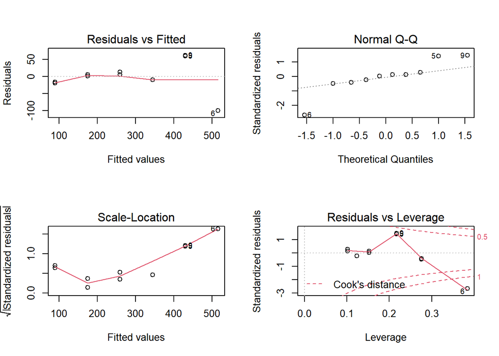

```r
par(mfrow=c(2,2))
plot(result)
```

```r
dwtest(result)
```

```
##
##  Durbin-Watson test
##
## data:  result
## DW = 2.4551, p-value = 0.7575
## alternative hypothesis: true autocorrelation is greater than 0
```

## (7)

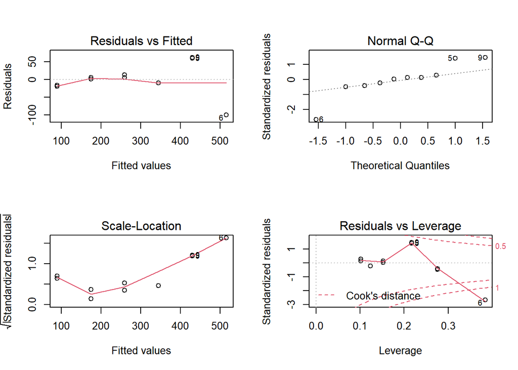

```r
par(mfrow=c(2,2))
plot(result)
```

```r
shapiro.test(residuals(result))
```

```
##
##  Shapiro-Wilk normality test
##
## data:  residuals(result)
## W = 0.88268, p-value = 0.1401
```

정규 Q-Q그림에서 그려진 점들이 선에서 크게 벗어나지 않으므로 정규분포를 따른다고 말할 수 있다.

## (8)

```r
pred = predict(result, newdata = data.frame(x=mean(x)))
pred
```

```
##     1
## 276.5
```

```r
confint(result)
```

```
##                   2.5 %     97.5 %
## (Intercept) -387.776628 -116.81758
## x              6.418293   10.63968
```

## (9)

```r
pred = predict(result, newdata = data.frame(x=c(45, 55, 65)))
pred
```

```
##        1        2        3
## 131.5072 216.7971 302.0870
```

```r
confint(result)
```

```
##                   2.5 %     97.5 %
## (Intercept) -387.776628 -116.81758
## x              6.418293   10.63968
```

## (10)

```r
summary(result)
```

```
##
## Call:
## lm(formula = y ~ x)
##
## Residuals:
##      Min       1Q   Median       3Q      Max
## -100.312  -15.080    3.203   10.880   61.978
##
## Coefficients:
##              Estimate Std. Error t value Pr(>|t|)
## (Intercept) -252.2971    58.7508  -4.294  0.00264 **
## x              8.5290     0.9153   9.318 1.43e-05 ***
## ---
## Signif. codes:  0 '***' 0.001 '**' 0.01 '*' 0.05 '.' 0.1 ' ' 1
##
## Residual standard error: 48.09 on 8 degrees of freedom
## Multiple R-squared:  0.9156, Adjusted R-squared:  0.9051
## F-statistic: 86.83 on 1 and 8 DF,  p-value: 1.434e-05
```

추정계수값: 8.5290 MSE: 48.09의 제곱 = 2312.6481 결정계수: 0.9156

# 3.

```r
sat <-  as.data.frame(read_excel("C:/Users/nabib/Documents/GitHub/Statics/1026/SAT성적.xlsx"))
sat
```

```
##    obs    Y   X1   X2 X3
## 1    1 2.04 2.01 1070  5
## 2    2 2.56 3.40 1254  6
## 3    3 3.75 3.68 1466  6
## 4    4 1.10 1.54  706  4
## 5    5 3.00 3.32 1160  5
## 6    6 0.05 0.33  756  3
## 7    7 1.38 0.36 1058  2
## 8    8 1.50 1.97 1008  7
## 9    9 1.38 2.03 1104  4
## 10  10 4.01 2.05 1200  7
## 11  11 1.50 2.13  896  7
## 12  12 1.29 1.34  848  3
## 13  13 1.90 1.51  958  5
## 14  14 3.11 3.12 1246  6
```

[output cut: 66 more lines]

## (1)

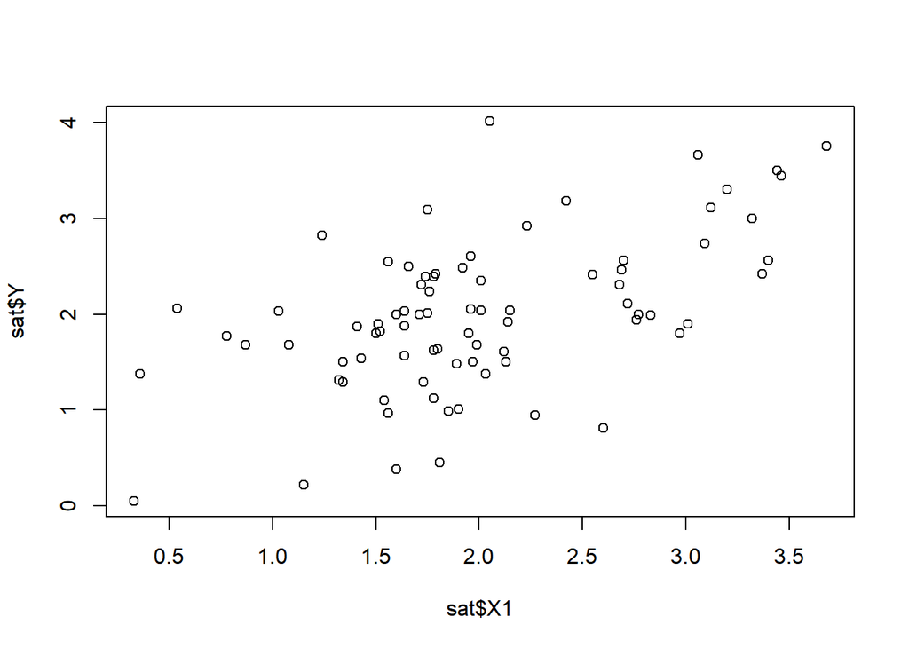

```r
plot(sat$X1, sat$Y)
```

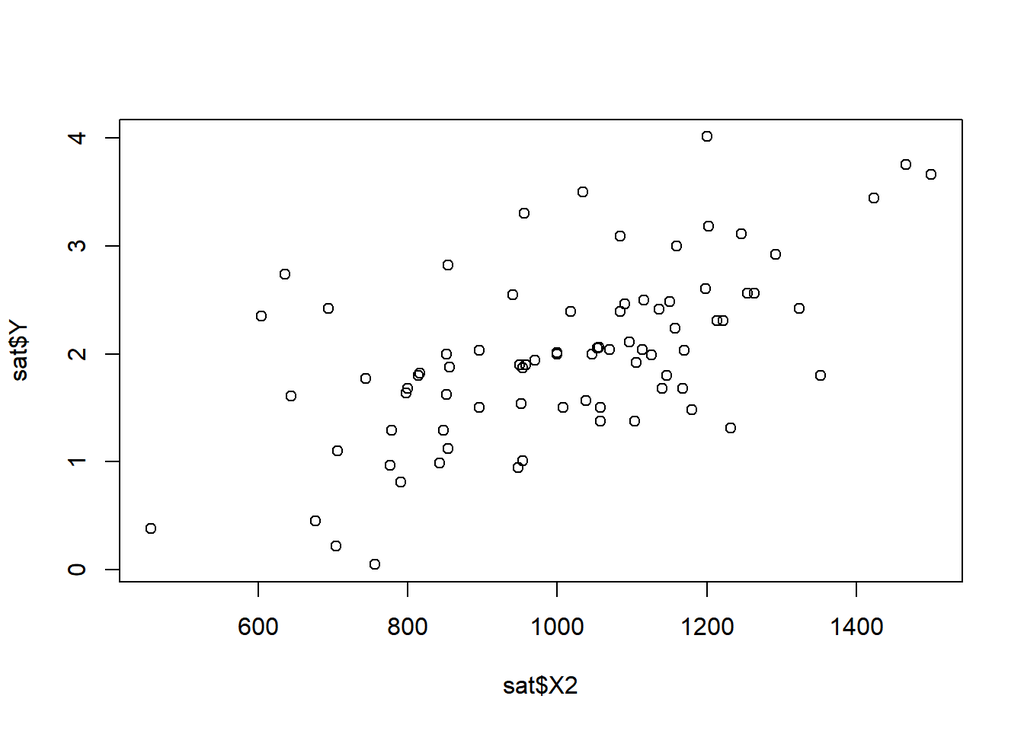

```r
plot(sat$X2, sat$Y)
```

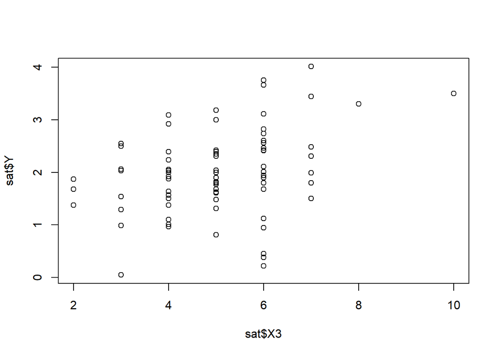

```r
plot(sat$X3, sat$Y)
```

## (2)

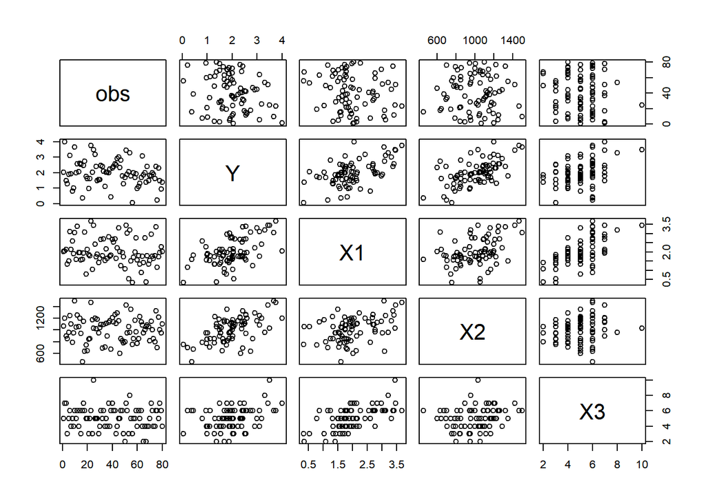

```r
par(mfrow=c(2,2))
plot(sat)
```

## (3)

```r
result3 = lm(Y ~ X1+X2+X3, data = sat)
result3
```

```
##
## Call:
## lm(formula = Y ~ X1 + X2 + X3, data = sat)
##
## Coefficients:
## (Intercept)           X1           X2           X3
##   -0.592091     0.359979     0.001692     0.032359
```

## (4)

```r
summary(result3)
```

```
##
## Call:
## lm(formula = Y ~ X1 + X2 + X3, data = sat)
##
## Residuals:
##      Min       1Q   Median       3Q      Max
## -1.07300 -0.39883  0.00594  0.35066  1.60751
##
## Coefficients:
##               Estimate Std. Error t value Pr(>|t|)
## (Intercept) -0.5920907  0.3740709  -1.583  0.11761
## X1           0.3599793  0.1234030   2.917  0.00464 **
## X2           0.0016918  0.0003474   4.869 5.95e-06 ***
## X3           0.0323591  0.0584113   0.554  0.58121
## ---
## Signif. codes:  0 '***' 0.001 '**' 0.01 '*' 0.05 '.' 0.1 ' ' 1
##
## Residual standard error: 0.5907 on 76 degrees of freedom
## Multiple R-squared:  0.4673, Adjusted R-squared:  0.4463
## F-statistic: 22.22 on 3 and 76 DF,  p-value: 1.965e-10
```

## (5)

```r
summary(result3)
```

```
##
## Call:
## lm(formula = Y ~ X1 + X2 + X3, data = sat)
##
## Residuals:
##      Min       1Q   Median       3Q      Max
## -1.07300 -0.39883  0.00594  0.35066  1.60751
##
## Coefficients:
##               Estimate Std. Error t value Pr(>|t|)
## (Intercept) -0.5920907  0.3740709  -1.583  0.11761
## X1           0.3599793  0.1234030   2.917  0.00464 **
## X2           0.0016918  0.0003474   4.869 5.95e-06 ***
## X3           0.0323591  0.0584113   0.554  0.58121
## ---
## Signif. codes:  0 '***' 0.001 '**' 0.01 '*' 0.05 '.' 0.1 ' ' 1
##
## Residual standard error: 0.5907 on 76 degrees of freedom
## Multiple R-squared:  0.4673, Adjusted R-squared:  0.4463
## F-statistic: 22.22 on 3 and 76 DF,  p-value: 1.965e-10
```

## (6)

```r
summary(result3)
```

```
##
## Call:
## lm(formula = Y ~ X1 + X2 + X3, data = sat)
##
## Residuals:
##      Min       1Q   Median       3Q      Max
## -1.07300 -0.39883  0.00594  0.35066  1.60751
##
## Coefficients:
##               Estimate Std. Error t value Pr(>|t|)
## (Intercept) -0.5920907  0.3740709  -1.583  0.11761
## X1           0.3599793  0.1234030   2.917  0.00464 **
## X2           0.0016918  0.0003474   4.869 5.95e-06 ***
## X3           0.0323591  0.0584113   0.554  0.58121
## ---
## Signif. codes:  0 '***' 0.001 '**' 0.01 '*' 0.05 '.' 0.1 ' ' 1
##
## Residual standard error: 0.5907 on 76 degrees of freedom
## Multiple R-squared:  0.4673, Adjusted R-squared:  0.4463
## F-statistic: 22.22 on 3 and 76 DF,  p-value: 1.965e-10
```

## (7)

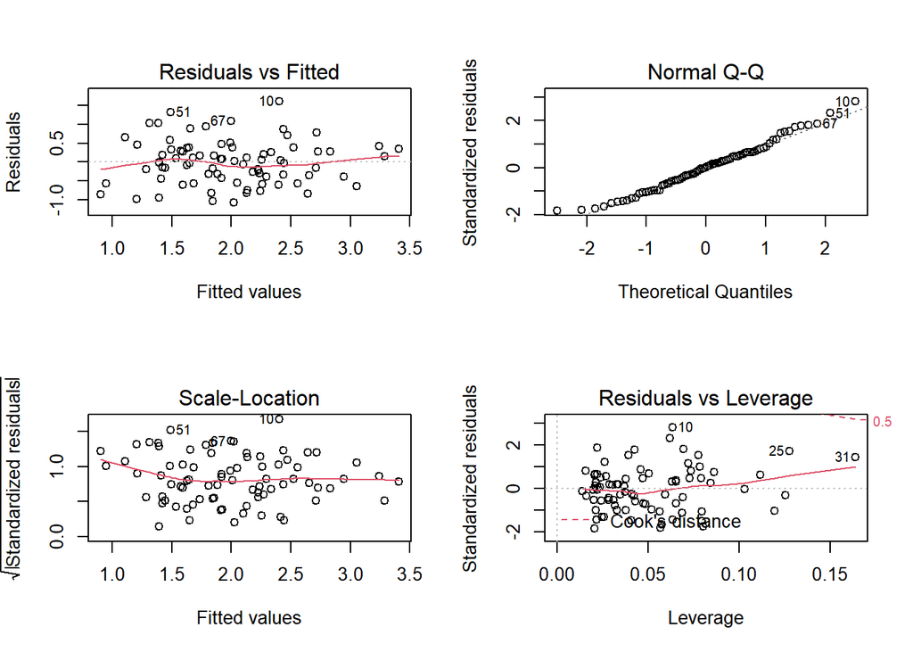

```r
par(mfrow=c(2,2))
plot(result3)
```

## (8)

```r
shapiro.test(residuals(result3))
```

```
##
##  Shapiro-Wilk normality test
##
## data:  residuals(result3)
## W = 0.98448, p-value = 0.445
```

## (9)

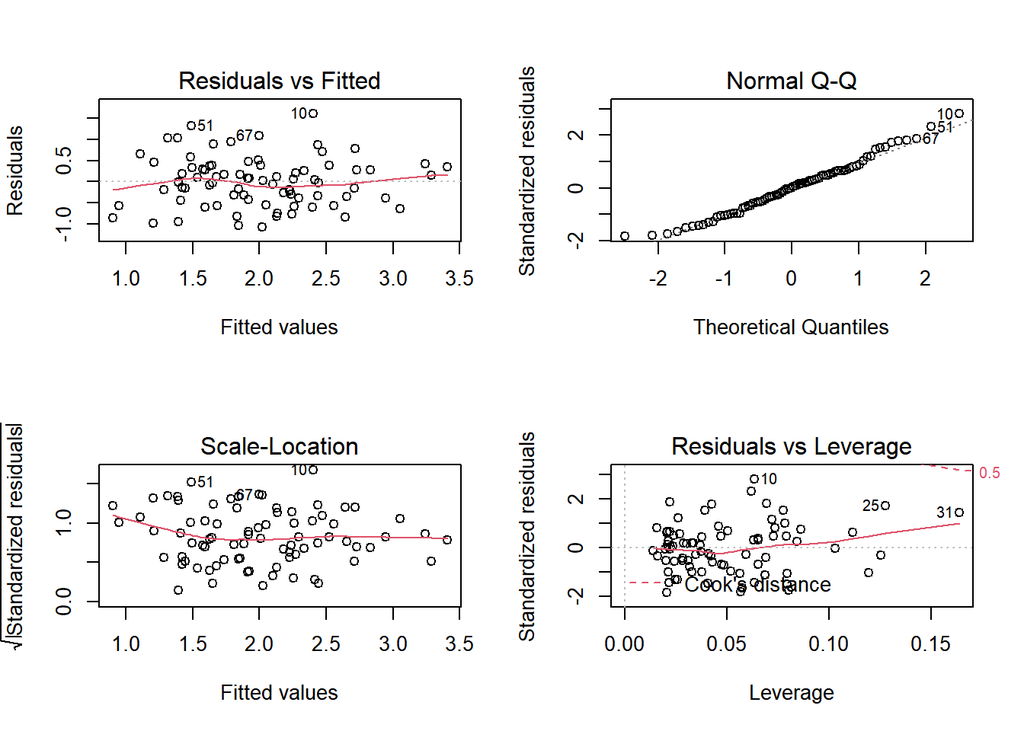

```r
par(mfrow=c(2,2))
plot(result3)
```

Q-Q plot에서 점들이 선에 몰려있기 때문에 정규분포를 따른다고 할 수 있다.

```r
shapiro.test(residuals(result3))
```

```
##
##  Shapiro-Wilk normality test
##
## data:  residuals(result3)
## W = 0.98448, p-value = 0.445
```

## (10)

```r
summary(result3)
```

```
##
## Call:
## lm(formula = Y ~ X1 + X2 + X3, data = sat)
##
## Residuals:
##      Min       1Q   Median       3Q      Max
## -1.07300 -0.39883  0.00594  0.35066  1.60751
##
## Coefficients:
##               Estimate Std. Error t value Pr(>|t|)
## (Intercept) -0.5920907  0.3740709  -1.583  0.11761
## X1           0.3599793  0.1234030   2.917  0.00464 **
## X2           0.0016918  0.0003474   4.869 5.95e-06 ***
## X3           0.0323591  0.0584113   0.554  0.58121
## ---
## Signif. codes:  0 '***' 0.001 '**' 0.01 '*' 0.05 '.' 0.1 ' ' 1
##
## Residual standard error: 0.5907 on 76 degrees of freedom
## Multiple R-squared:  0.4673, Adjusted R-squared:  0.4463
## F-statistic: 22.22 on 3 and 76 DF,  p-value: 1.965e-10
```

X1, X2, X3에 곱해지는 값이 각각 0.36, 0.00, 0.03이다. 즉 X1에 곱해지는 값이 가장 크기 때문에 y를 결정하는데 가장 영향을 준다고 할 수 있다.

## (11)

```r
summary(result3)
```

```
##
## Call:
## lm(formula = Y ~ X1 + X2 + X3, data = sat)
##
## Residuals:
##      Min       1Q   Median       3Q      Max
## -1.07300 -0.39883  0.00594  0.35066  1.60751
##
## Coefficients:
##               Estimate Std. Error t value Pr(>|t|)
## (Intercept) -0.5920907  0.3740709  -1.583  0.11761
## X1           0.3599793  0.1234030   2.917  0.00464 **
## X2           0.0016918  0.0003474   4.869 5.95e-06 ***
## X3           0.0323591  0.0584113   0.554  0.58121
## ---
## Signif. codes:  0 '***' 0.001 '**' 0.01 '*' 0.05 '.' 0.1 ' ' 1
##
## Residual standard error: 0.5907 on 76 degrees of freedom
## Multiple R-squared:  0.4673, Adjusted R-squared:  0.4463
## F-statistic: 22.22 on 3 and 76 DF,  p-value: 1.965e-10
```

## (12)

```r
confint(result3)
```

```
##                     2.5 %      97.5 %
## (Intercept) -1.3371175678 0.152936091
## X1           0.1142009364 0.605757603
## X2           0.0009997853 0.002383727
## X3          -0.0839770756 0.148695192
```

## (13)

```r
summary(result3)
```

```
##
## Call:
## lm(formula = Y ~ X1 + X2 + X3, data = sat)
##
## Residuals:
##      Min       1Q   Median       3Q      Max
## -1.07300 -0.39883  0.00594  0.35066  1.60751
##
## Coefficients:
##               Estimate Std. Error t value Pr(>|t|)
## (Intercept) -0.5920907  0.3740709  -1.583  0.11761
## X1           0.3599793  0.1234030   2.917  0.00464 **
## X2           0.0016918  0.0003474   4.869 5.95e-06 ***
## X3           0.0323591  0.0584113   0.554  0.58121
## ---
## Signif. codes:  0 '***' 0.001 '**' 0.01 '*' 0.05 '.' 0.1 ' ' 1
##
## Residual standard error: 0.5907 on 76 degrees of freedom
## Multiple R-squared:  0.4673, Adjusted R-squared:  0.4463
## F-statistic: 22.22 on 3 and 76 DF,  p-value: 1.965e-10
```

추정계수값: 0.359 MSE: 0.5907의 제곱 = 0.34893 결정계수: 0.4673